# Reproducible Research: Peer Assessment 1

# Dataset

The dataset for this assigment can be found here [Activity Monitoring Data](https://d396qusza40orc.cloudfront.net/repdata%2Fdata%2Factivity.zip)

# Variables

- steps: Number of steps taking in a 5-minute interval (missing values are coded as NA)
- date: The date on which the measurement was taken in YYYY-MM-DD format
- interval: Identifier for the 5-minute interval in which measurement was taken

# The analysis

## Loading and preprocessing the data

```r
activity <- read.csv("./activity.csv", sep=",", header=TRUE)
```

```r
activity$date <- as.Date(activity$date)
```

### Calculate the number of steps taken by day

```r
steps <- aggregate(steps ~ date, data = activity, sum)
```

### Make a histogram of the total number of steps taken each day

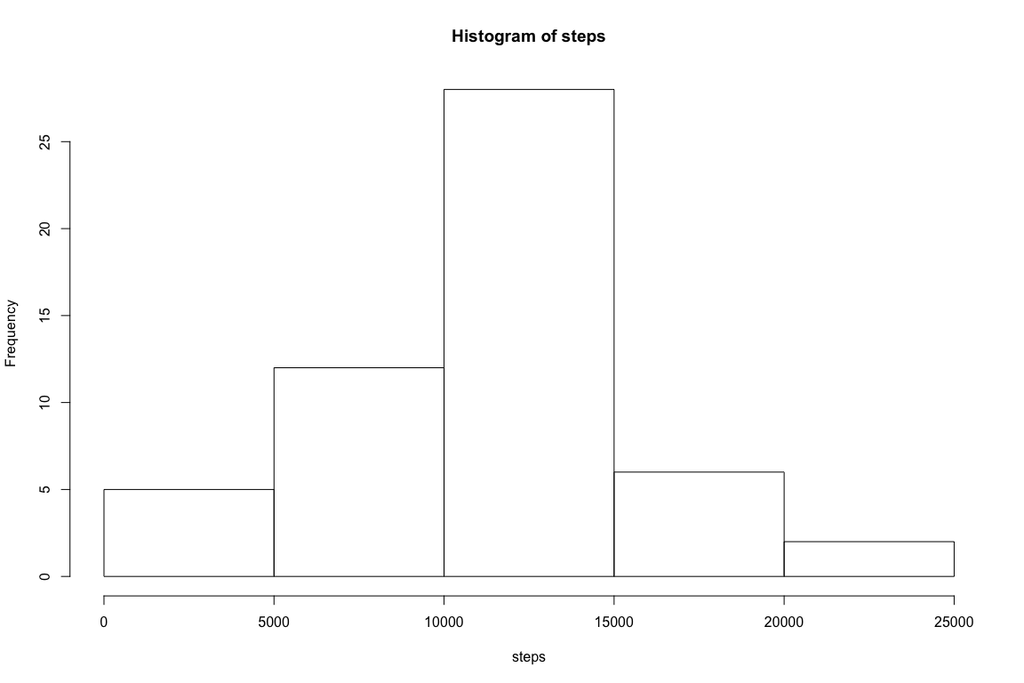

```r
histsteps <- with(steps, hist(steps))
```

```r
meansteps <- mean(steps$steps, na.rm = TRUE)
mediansteps <- median(steps$steps, na.rm= TRUE)
```

## What is the average daily activity pattern?

### Make a time series plot of the 5-minute interval (x-axis) and the average number of steps taken, averaged across all days (y-axis)

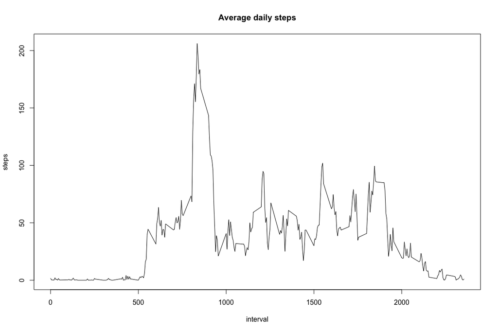

```r
avgsteps <- aggregate(steps ~ interval, data = activity, mean)
with(avgsteps, plot(steps ~ interval, type = "l", main="Average daily steps"))
```

### Which 5-minute interval, on average across all the days in the dataset, contains the maximum number of steps?

```r
avgsteps[which.max(avgsteps$steps),]
```

```
##     interval    steps
## 104      835 206.1698
```

## Imputing missing values

```r
sum(is.na(activity$steps))
```

```
## [1] 2304
```

### Devise a strategy for filling in all of the missing values in the dataset. The strategy does not need to be sophisticated. For example, you could use the mean/median for that day, or the mean for that 5-minute interval, etc. Create a new dataset that is equal to the original dataset but with the missing data filled in.

```r
activitynomissingvalues <- transform(activity, steps = ifelse(is.na(activity$steps), avgsteps$steps[match(activity$interval, avgsteps$interval)], activity$steps))
sum(is.na(activitynomissingvalues$steps))
```

```
## [1] 0
```

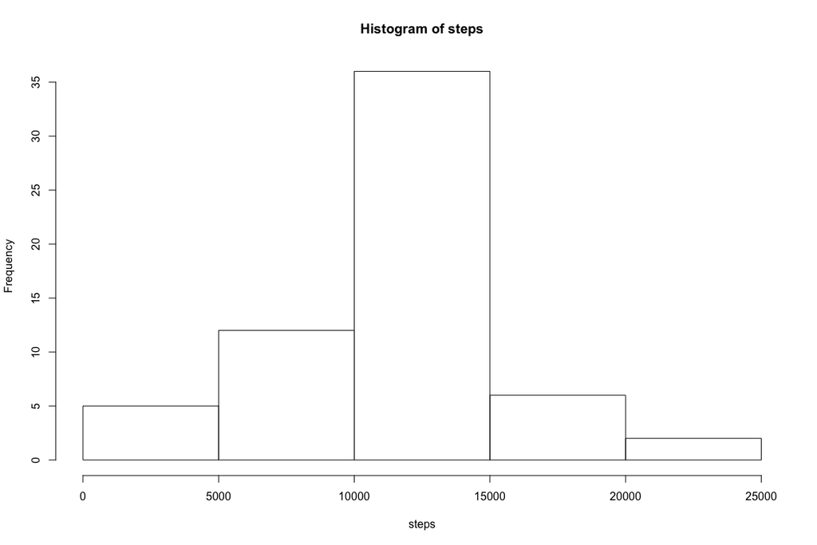

```r
stepsnomissingvalues <- aggregate(steps ~ date, data = activitynomissingvalues, sum)
with(stepsnomissingvalues, hist(steps))
```

```r
meanstepsnomissingvalues <- mean(stepsnomissingvalues$steps)
medianstepsnomissingvalues <- median(stepsnomissingvalues$steps)
```

```r
mean_diff <- meansteps - meanstepsnomissingvalues
median_diff <- mediansteps - medianstepsnomissingvalues
```

## Are there differences in activity patterns between weekdays and weekends?

### Create a new factor variable in the dataset with two levels (weekday and weekend) indicating whether a given date is a weekday or weekend day.

```r
activitynomissingvalues$weekdays <- weekdays(activitynomissingvalues$date)

for (i in 1:nrow(activitynomissingvalues)) {
  if ((activitynomissingvalues$weekdays[i] == "Saturday") | (activitynomissingvalues$weekdays[i] == "Sunday")) {
    activitynomissingvalues$wd[i] = "weekend"
  } else {
    activitynomissingvalues$wd[i] = "weekday"
  }
}

activityweekday <- subset(activitynomissingvalues, wd=="weekday")
activityweekend<- subset(activitynomissingvalues, wd=="weekend")

avgstepsweekday <- aggregate(steps ~ interval, data = activityweekday, mean)
avgstepsweekend <- aggregate(steps ~ interval, data = activityweekend, mean)
```

### Make a panel plot containing a time series plot of the 5-minute interval and the average number of steps taken, averaged across all weekday days or weekend days.

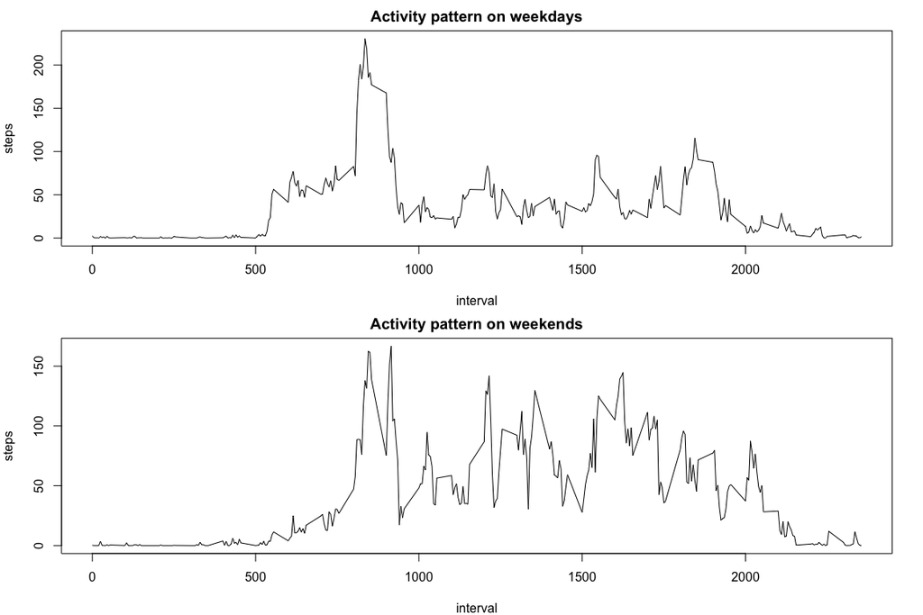

```r
par(mfrow=c(2,1), mar=c(4,4,2,2))
plot(steps ~ interval, data = avgstepsweekday, type="l", ylab="steps", xlab="interval", main="Activity pattern on weekdays")
plot(steps ~ interval, data=avgstepsweekend, type="l", ylab="steps", xlab="interval", main="Activity pattern on weekends")
```